# Aurora Market: Data Familiarization

FSAR 2026 · Group H · Scoping Brief, section 1.1

01 October 2026

# Purpose and approach

This document explores all seven Aurora Market tables before any cleaning. For each table we check its **dimensions and unit of observation**, **identifiers**, **missing values**, **duplicates**, **unusual numeric or categorical values**, and other **consistency issues**. We then look at **how the tables connect**. Nothing here modifies the data; every number is computed from the original CSV files in `Data/`.

The same analysis is available as a console script in `R/02_data_familiarization.R`.

# 1 Loading the data

Every column gets an explicit type. All `*_timestamp` columns and `shipping_deadline` are parsed as UTC date-times, as the README requires.

```r
dt <- col_datetime(format = "")
spec <- list(
  customers = cols(.default = col_character()),
  orders = cols(.default = col_character(),
                purchase_timestamp = dt, approval_timestamp = dt, carrier_timestamp = dt,
                delivery_timestamp = dt, estimated_delivery_timestamp = dt),
  order_items = cols(.default = col_character(), item_number = col_integer(),
                     shipping_deadline = dt, item_price = col_double(), freight_cost = col_double()),
  products = cols(.default = col_double(), product_id = col_character(), product_category = col_character()),
  sellers = cols(.default = col_character()),
  payments = cols(.default = col_character(), payment_sequence = col_integer(),
                  installments = col_integer(), payment_amount = col_double()),
  customer_feedback = cols(.default = col_character(), rating = col_integer(),
                           has_title = col_logical(), has_comment = col_logical(),
                           comment_length = col_integer(),
                           feedback_created_timestamp = dt, feedback_answered_timestamp = dt))

d <- lapply(names(spec), function(t) read_csv(file.path("Data", paste0(t, ".csv")),
                                              col_types = spec[[t]], na = c("", "NA")))
names(d) <- names(spec)
customers <- d$customers; orders <- d$orders; items <- d$order_items
products <- d$products; sellers <- d$sellers; payments <- d$payments; feedback <- d$customer_feedback

parse_issues <- vapply(d, function(x) nrow(problems(x)), integer(1))
```

Parsing problems across all tables: **0**. Every value matched its declared type.

# 2 Overview of the seven tables

```r
overview <- tibble(
  table = names(d),
  rows = vapply(d, nrow, integer(1)),
  columns = vapply(d, ncol, integer(1)),
  cells_missing = vapply(d, function(x) sum(is.na(x)), integer(1)),
  exact_duplicate_rows = vapply(d, function(x) sum(duplicated(x)), integer(1)),
  unit_of_observation = c("customer record (one per order)", "order", "item line within an order",
                          "product listing", "seller", "payment within an order", "feedback record"))
tbl(overview)
```

| table | rows | columns | cells_missing | exact_duplicate_rows | unit_of_observation |
| --- | --- | --- | --- | --- | --- |
| customers | 82,570 | 5 | 0 | 0 | customer record (one per order) |
| orders | 82,570 | 8 | 4,113 | 0 | order |
| order_items | 93,519 | 7 | 0 | 60 | item line within an order |
| products | 29,389 | 9 | 2,140 | 0 | product listing |
| sellers | 2,983 | 4 | 0 | 0 | seller |
| payments | 86,345 | 5 | 0 | 0 | payment within an order |
| customer_feedback | 82,380 | 8 | 0 | 0 | feedback record |

The tables are at **different units of observation**. Only `orders` and `customers` share the same grain, and three tables (`order_items`, `payments`, `customer_feedback`) can have several rows per order.

# 3 customers

```r
tbl(profile_columns(customers), caption = "Column profile")
```

Column profile

| column | type | n_missing | pct_missing | n_distinct | example |
| --- | --- | --- | --- | --- | --- |
| customer_record_id | character | 0 | 0 | 82,570 | CUSTOMER_RECORD_VWFMUDXRCO |
| customer_id | character | 0 | 0 | 79,759 | CUSTOMER_DDMXDQQBRK |
| postal_area | character | 0 | 0 | 14,397 | AREA_JCYKOHZ |
| city | character | 0 | 0 | 4,032 | CITY_CYDNXG |
| region | character | 0 | 0 | 27 | REGION_ZMUB |

## 3.1 Identifiers

```r
rec_per_cust <- customers %>% count(customer_id, name = "records")
n_multi <- sum(rec_per_cust$records > 1)
tbl(bind_rows(key_info(customers, "customer_record_id"), key_info(customers, "customer_id")))
```

| key | rows | distinct | extra_rows | unique |
| --- | --- | --- | --- | --- |
| customer_record_id | 82,570 | 82,570 | 0 | TRUE |
| customer_id | 82,570 | 79,759 | 2,811 | FALSE |

```r
tbl(rec_per_cust %>% count(records, name = "customers") %>% mutate(pct = round(100 * customers / sum(customers), 2)),
    caption = "Records per customer_id")
```

Records per customer_id

| records | customers | pct |
| --- | --- | --- |
| 1 | 77,246 | 96.85 |
| 2 | 2,297 | 2.88 |
| 3 | 174 | 0.22 |
| 4 | 27 | 0.03 |
| 5 | 6 | 0.01 |
| 6 | 5 | 0.01 |
| 7 | 2 | 0.00 |
| 9 | 1 | 0.00 |
| 17 | 1 | 0.00 |

`customer_record_id` is unique, but **`customer_id` is not**. 2,513 people (3.15%) have more than one record, and one has 17. As Section 4 shows, a *record* is created per order. Customer-level questions (repeat purchase, lifetime value) must therefore group by `customer_id`.

```r
loc <- customers %>% semi_join(filter(rec_per_cust, records > 1), by = "customer_id") %>%
  group_by(customer_id) %>%
  summarise(postal = n_distinct(postal_area), city = n_distinct(city), region = n_distinct(region))
pa_city  <- customers %>% distinct(postal_area, city) %>% count(postal_area) %>% filter(n > 1)
city_reg <- customers %>% distinct(city, region) %>% count(city) %>% filter(n > 1)
```

**Location is stored per record, not per person.** Of the 2,513 repeat customers, 221 change postal area, 105 change city and 36 change region between records. It most likely reflects the delivery address of each order.

**Geography hierarchy.** There are 14,397 postal areas, 4,032 cities and 27 regions. Each postal area maps to a single city (0 exceptions). However, **25 city identifiers appear in more than one region**, so city codes are not safe as a standalone geographic key.

```r
reg <- freq(customers, region)
tbl(reg, n = 10, caption = "Customer records by region")
```

Customer records by region (first 10 of 27 rows)

| region | n | pct |
| --- | --- | --- |
| REGION_ZAQW | 34,702 | 42.03 |
| REGION_WSPK | 10,660 | 12.91 |
| REGION_ZMUB | 9,606 | 11.63 |
| REGION_DYWE | 4,536 | 5.49 |
| REGION_SNJF | 4,164 | 5.04 |
| REGION_FLVI | 3,029 | 3.67 |
| REGION_ZDZK | 2,810 | 3.40 |
| REGION_BQGV | 1,792 | 2.17 |
| REGION_RYAS | 1,690 | 2.05 |
| REGION_CGSL | 1,667 | 2.02 |

Customers are highly concentrated: REGION_ZAQW alone holds **42.03%** of records, and the smallest regions have fewer than 100. Region-level estimates for small regions will be imprecise.

# 4 orders

```r
tbl(profile_columns(orders), caption = "Column profile")
```

Column profile

| column | type | n_missing | pct_missing | n_distinct | example |
| --- | --- | --- | --- | --- | --- |
| order_id | character | 0 | 0.00 | 82,570 | ORDER_ZFLVAAESEC |
| customer_record_id | character | 0 | 0.00 | 82,570 | CUSTOMER_RECORD_RGOSZADINE |
| order_status | character | 0 | 0.00 | 8 | COMPLETED |
| purchase_timestamp | POSIXct | 0 | 0.00 | 82,151 | 2023-03-05 23:52:10 |
| approval_timestamp | POSIXct | 126 | 0.15 | 76,338 | 2023-03-06 01:05:37 |
| carrier_timestamp | POSIXct | 1,497 | 1.81 | 68,786 | 2023-03-20 07:14:11 |
| delivery_timestamp | POSIXct | 2,490 | 3.02 | 79,540 | 2023-03-23 15:07:38 |
| estimated_delivery_timestamp | POSIXct | 0 | 0.00 | 457 | 2023-04-07 |

```r
tbl(bind_rows(key_info(orders, "order_id"), key_info(orders, "customer_record_id")))
```

| key | rows | distinct | extra_rows | unique |
| --- | --- | --- | --- | --- |
| order_id | 82,570 | 82,570 | 0 | TRUE |
| customer_record_id | 82,570 | 82,570 | 0 | TRUE |

Both `order_id` and `customer_record_id` are unique here. Orders and customer records are therefore **1:1**.

## 4.1 Order status and structured missingness

```r
miss_status <- orders %>% group_by(order_status) %>%
  summarise(orders = n(), no_approval = sum(is.na(approval_timestamp)),
            no_carrier = sum(is.na(carrier_timestamp)), no_delivery = sum(is.na(delivery_timestamp))) %>%
  arrange(desc(orders)) %>% mutate(pct_orders = round(100 * orders / sum(orders), 2), .after = orders)
tbl(miss_status)
```

| order_status | orders | pct_orders | no_approval | no_carrier | no_delivery |
| --- | --- | --- | --- | --- | --- |
| COMPLETED | 80,082 | 96.99 | 12 | 1 | 7 |
| IN_TRANSIT | 932 | 1.13 | 0 | 0 | 932 |
| CANCELLED | 517 | 0.63 | 109 | 457 | 512 |
| UNAVAILABLE | 507 | 0.61 | 0 | 507 | 507 |
| BILLED | 268 | 0.32 | 0 | 268 | 268 |
| PROCESSING | 257 | 0.31 | 0 | 257 | 257 |
| PLACED | 5 | 0.01 | 5 | 5 | 5 |
| APPROVED | 2 | 0.00 | 0 | 2 | 2 |

```r
cmp_no_del <- sum(orders$order_status == "COMPLETED" & is.na(orders$delivery_timestamp))
canc_del   <- sum(orders$order_status == "CANCELLED" & !is.na(orders$delivery_timestamp))
```

96.99% of orders are COMPLETED. Missing timestamps are **not random**: they follow the order status. An order that never shipped has no carrier or delivery date. Missing delivery dates are therefore meaningful information, not a cleaning problem to drop. There are small contradictions: 7 COMPLETED orders have no delivery date, and 5 CANCELLED orders have one.

## 4.2 Time coverage

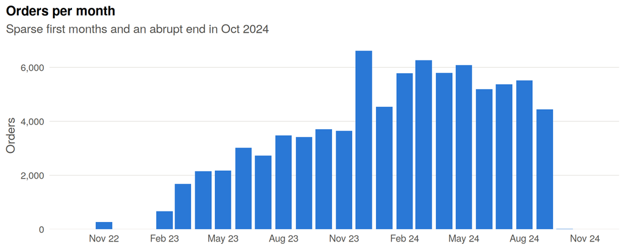

```r
monthly <- orders %>% count(month = as.Date(format(purchase_timestamp, "%Y-%m-01")))
monthly <- tibble(month = seq(min(monthly$month), max(monthly$month), by = "month")) %>%
  left_join(monthly, by = "month") %>% mutate(n = coalesce(n, 0L))
thin <- monthly %>% filter(n < 100)
ggplot(monthly, aes(month, n)) +
  geom_col(fill = col_main, width = 25) +
  scale_y_continuous(labels = scales::comma, expand = expansion(mult = c(0, .05))) +
  scale_x_date(date_breaks = "3 months", date_labels = "%b %y") +
  labs(title = "Orders per month", subtitle = "Sparse first months and an abrupt end in Oct 2024",
       x = NULL, y = "Orders")
```

Purchases run from 02 Oct 2022 to 13 Nov 2024. Months with fewer than 100 orders: Oct 2022 (8), Dec 2022 (0), Jan 2023 (1), Oct 2024 (10), Nov 2024 (2). These edge months are not comparable to the rest and should probably be excluded from any trend or seasonal analysis. There is also a visible peak in December 2023.

## 4.3 Chronological consistency

```r
seq_checks <- tibble(
  check = c("approval before purchase", "carrier handover before approval",
            "carrier handover before purchase", "delivery before carrier handover",
            "delivery before purchase", "estimated delivery before purchase"),
  orders = c(sum(orders$approval_timestamp < orders$purchase_timestamp, na.rm = TRUE),
             sum(orders$carrier_timestamp < orders$approval_timestamp, na.rm = TRUE),
             sum(orders$carrier_timestamp < orders$purchase_timestamp, na.rm = TRUE),
             sum(orders$delivery_timestamp < orders$carrier_timestamp, na.rm = TRUE),
             sum(orders$delivery_timestamp < orders$purchase_timestamp, na.rm = TRUE),
             sum(orders$estimated_delivery_timestamp < orders$purchase_timestamp, na.rm = TRUE)))
tbl(seq_checks)
```

| check | orders |
| --- | --- |
| approval before purchase | 0 |
| carrier handover before approval | 1,109 |
| carrier handover before purchase | 141 |
| delivery before carrier handover | 18 |
| delivery before purchase | 0 |
| estimated delivery before purchase | 0 |

The order lifecycle should run purchase → approval → carrier → delivery. **1,109 orders reach the carrier before approval** and 141 before the purchase itself. This matters for any variable built from stage durations, such as “seller handling time”.

## 4.4 Delivery performance

```r
del <- orders %>% filter(!is.na(delivery_timestamp)) %>%
  mutate(delivery_days = as.numeric(difftime(delivery_timestamp, purchase_timestamp, units = "days")),
         promised_days = as.numeric(difftime(estimated_delivery_timestamp, purchase_timestamp, units = "days")),
         days_vs_estimate = as.numeric(difftime(delivery_timestamp, estimated_delivery_timestamp, units = "days")))
late_time <- mean(del$days_vs_estimate > 0)
late_date <- mean(as.Date(del$delivery_timestamp) > as.Date(del$estimated_delivery_timestamp))
tbl(numeric_summary(select(del, delivery_days, promised_days, days_vs_estimate)))
```

| variable | n_na | min | p01 | median | mean | p99 | max | n_zero | n_neg |
| --- | --- | --- | --- | --- | --- | --- | --- | --- | --- |
| days_vs_estimate | 0 | -146.02 | -35.12 | -11.73 | -11.15 | 19.62 | 188.98 | 0 | 73,565 |
| delivery_days | 0 | 0.53 | 1.83 | 10.22 | 12.57 | 46.18 | 209.63 | 0 | 0 |
| promised_days | 0 | 2.01 | 6.08 | 23.22 | 23.72 | 50.21 | 155.14 | 0 | 0 |

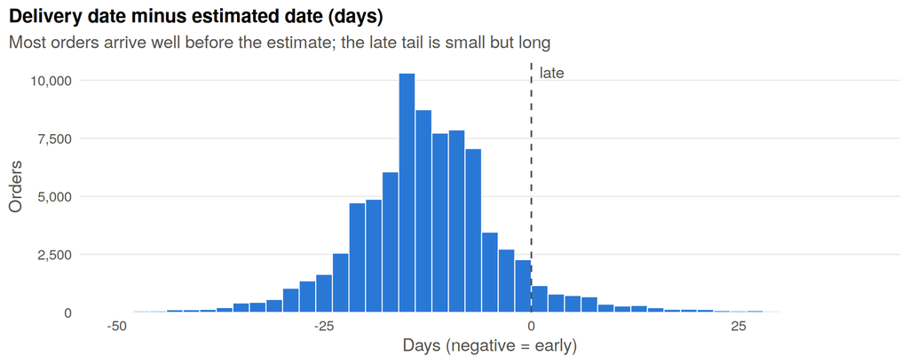

```r
ggplot(del, aes(as.numeric(as.Date(delivery_timestamp) - as.Date(estimated_delivery_timestamp)))) +
  geom_histogram(binwidth = 2, boundary = 0, fill = col_main, colour = "white", linewidth = 0.3) +
  geom_vline(xintercept = 0, colour = ink, linetype = "dashed") +
  coord_cartesian(xlim = c(-50, 40)) +
  scale_y_continuous(labels = scales::comma, expand = expansion(mult = c(0, .05))) +
  annotate("text", x = 1, y = Inf, label = "late", hjust = 0, vjust = 1.5, colour = ink, size = 3.5) +
  labs(title = "Delivery date minus estimated date (days)",
       subtitle = "Most orders arrive well before the estimate; the late tail is small but long",
       x = "Days (negative = early)", y = "Orders")
```

The median delivery takes **10.2 days**, against a median promise of 23.2 days. The estimate is always recorded at 00:00, so it is a *date*, while the actual delivery has a precise time. Comparing raw timestamps labels 8.14% of orders late. Comparing calendar dates gives **6.80%**. A “late” variable should be built from dates.

# 5 order_items

```r
tbl(profile_columns(items), caption = "Column profile")
```

Column profile

| column | type | n_missing | pct_missing | n_distinct | example |
| --- | --- | --- | --- | --- | --- |
| order_id | character | 0 | 0 | 81,929 | ORDER_FFVDVDZCJY |
| item_number | integer | 0 | 0 | 21 | 1 |
| product_id | character | 0 | 0 | 29,404 | PRODUCT_VODSDUFVBN |
| seller_id | character | 0 | 0 | 2,983 | SELLER_XJMPQYDRDT |
| shipping_deadline | POSIXct | 0 | 0 | 78,153 | 2024-04-29 22:27:56 |
| item_price | numeric | 0 | 0 | 5,503 | 354.5 |
| freight_cost | numeric | 0 | 0 | 6,558 | 25.65 |

## 5.1 Identifiers and duplicates

```r
n_exact <- sum(duplicated(items))
dup_keys <- items %>% group_by(order_id, item_number) %>% filter(n() > 1) %>% ungroup()
tbl(key_info(items, c("order_id", "item_number")))
```

| key | rows | distinct | extra_rows | unique |
| --- | --- | --- | --- | --- |
| order_id + item_number | 93,519 | 93,459 | 60 | FALSE |

```r
tbl(head(dup_keys, 4), caption = "Example of duplicated item lines")
```

Example of duplicated item lines

| order_id | item_number | product_id | seller_id | shipping_deadline | item_price | freight_cost |
| --- | --- | --- | --- | --- | --- | --- |
| ORDER_HGEWTNBDQD | 1 | PRODUCT_NIMYLLCLQL | SELLER_WIJJPLXLDI | 2024-07-11 12:57:00 | 128.78 | 42.89 |
| ORDER_HJUVZHBGTV | 1 | PRODUCT_WJJOAWXOAE | SELLER_MJAWMANGZK | 2024-05-23 18:31:38 | 300.03 | 22.48 |
| ORDER_APHSGKPROT | 1 | PRODUCT_YRPTKCKXHY | SELLER_IXHYUYATJQ | 2024-01-17 10:31:37 | 178.09 | 19.88 |
| ORDER_GUIVZLNDOU | 1 | PRODUCT_LVZKPCSKHO | SELLER_TLRVEKDFRH | 2024-06-06 14:53:34 | 95.89 | 25.17 |

```r
numbering <- items %>% distinct(order_id, item_number) %>% group_by(order_id) %>%
  summarise(n = n(), mx = max(item_number), mn = min(item_number))
```

The intended key (`order_id`, `item_number`) is **not unique**. There are 60 exact duplicate rows, identical in every column. Section 8.2 shows that payments match the totals *without* these duplicates, so they are recording errors. Item numbers otherwise run 1…n with no gaps (0 exceptions).

## 5.2 Order composition

```r
per_order <- items %>% distinct() %>% group_by(order_id) %>%
  summarise(items = n(), products = n_distinct(product_id), sellers = n_distinct(seller_id))
tbl(freq(per_order, items) %>% arrange(items), n = 8, caption = "Item lines per order")
```

Item lines per order (first 8 of 17 rows)

| items | n | pct |
| --- | --- | --- |
| 1 | 73,820 | 90.10 |
| 2 | 6,231 | 7.61 |
| 3 | 1,098 | 1.34 |
| 4 | 408 | 0.50 |
| 5 | 165 | 0.20 |
| 6 | 158 | 0.19 |
| 7 | 18 | 0.02 |
| 8 | 7 | 0.01 |

90.10% of orders contain a single item. 1,052 orders (1.28%) involve more than one seller. In 5,763 orders the same product appears on several lines. There is no quantity column; **quantity is represented by repeated lines**.

## 5.3 Prices, freight and shipping deadlines

```r
sd <- items %>% distinct() %>% left_join(select(orders, order_id, purchase_timestamp), by = "order_id") %>%
  mutate(deadline_days = as.numeric(difftime(shipping_deadline, purchase_timestamp, units = "days")))
tbl(numeric_summary(bind_cols(select(items %>% distinct(), item_price, freight_cost), select(sd, deadline_days))))
```

| variable | n_na | min | p01 | median | mean | p99 | max | n_zero | n_neg |
| --- | --- | --- | --- | --- | --- | --- | --- | --- | --- |
| deadline_days | 0 | 2.00 | 2.01 | 6.01 | 6.65 | 19.01 | 1,056.04 | 0 | 0 |
| freight_cost | 0 | 0.00 | 6.17 | 22.30 | 27.35 | 115.61 | 561.26 | 319 | 0 |
| item_price | 0 | 1.16 | 13.69 | 102.74 | 165.38 | 1,218.04 | 9,218.73 | 0 | 0 |

# 6 products

```r
tbl(profile_columns(products), caption = "Column profile")
```

Column profile

| column | type | n_missing | pct_missing | n_distinct | example |
| --- | --- | --- | --- | --- | --- |
| product_id | character | 0 | 0.00 | 29,389 | PRODUCT_NTRQXSOMQP |
| product_category | character | 533 | 1.81 | 78 | HOUSEHOLD_GOODS |
| name_length | numeric | 533 | 1.81 | 65 | 56 |
| description_length | numeric | 533 | 1.81 | 2,892 | 382 |
| photo_count | numeric | 533 | 1.81 | 19 | 1 |
| weight_g | numeric | 2 | 0.01 | 2,109 | 2140 |
| length_cm | numeric | 2 | 0.01 | 99 | 18 |
| height_cm | numeric | 2 | 0.01 | 101 | 26 |
| width_cm | numeric | 2 | 0.01 | 95 | 19 |

```r
tbl(key_info(products, "product_id"))
```

| key | rows | distinct | extra_rows | unique |
| --- | --- | --- | --- | --- |
| product_id | 29,389 | 29,389 | 0 | TRUE |

## 6.1 Missing values come in one block

```r
tbl(products %>%
  transmute(category_missing = is.na(product_category),
            listing_info_missing = is.na(name_length) & is.na(description_length) & is.na(photo_count),
            dimensions_missing = is.na(weight_g) & is.na(length_cm) & is.na(height_cm) & is.na(width_cm)) %>%
  count(category_missing, listing_info_missing, dimensions_missing))
```

| category_missing | listing_info_missing | dimensions_missing | n |
| --- | --- | --- | --- |
| FALSE | FALSE | FALSE | 28,855 |
| FALSE | FALSE | TRUE | 1 |
| TRUE | TRUE | FALSE | 532 |
| TRUE | TRUE | TRUE | 1 |

The category, name length, description length and photo count are missing **together for the same 533 products**. That is one missing-data pattern (listings created without metadata), not four separate problems. Only 2 products lack physical dimensions.

## 6.2 Category labels are inconsistently spelled

```r
normalise_cat <- function(x) {
  x %>% toupper() %>% str_replace_all("[^A-Z]+", "_") %>% str_replace_all("_+", "_") %>%
    str_replace_all("^_|_$", "") %>% str_replace("^HOUSEHOLDGOODS$", "HOUSEHOLD_GOODS")
}
cat_map <- products %>% filter(!is.na(product_category)) %>% distinct(product_category) %>%
  mutate(normalised = normalise_cat(product_category))
tbl(cat_map %>% group_by(normalised) %>% filter(n() > 1) %>% arrange(normalised) %>%
      left_join(count(products, product_category, name = "products"), by = "product_category"),
    caption = "Labels that refer to the same category")
```

Labels that refer to the same category

| product_category | normalised | products |
| --- | --- | --- |
| BEAUTY_AND_WELLNESS | BEAUTY_AND_WELLNESS | 2,161 |
| BEAUTY__AND__WELLNESS | BEAUTY_AND_WELLNESS | 24 |
| FURNITURE_AND_HOME_DECOR | FURNITURE_AND_HOME_DECOR | 2,302 |
| FURNITURE-AND-HOME-DECOR | FURNITURE_AND_HOME_DECOR | 24 |
| HOME_LINENS_AND_BATH | HOME_LINENS_AND_BATH | 2,674 |
| home_linens_and_bath | HOME_LINENS_AND_BATH | 24 |
| HOUSEHOLD_GOODS | HOUSEHOLD_GOODS | 2,054 |
| HOUSEHOLDGOODS | HOUSEHOLD_GOODS | 24 |
| SPORTS_AND_RECREATION | SPORTS_AND_RECREATION | 2,547 |
| SPORTS AND RECREATION | SPORTS_AND_RECREATION | 24 |

There are **78 raw labels but only 73 real categories**. Five categories also appear in variant spellings: lowercase, hyphens, spaces, doubled or missing underscores. Each variant holds exactly 24 products, which suggests they were introduced deliberately and must be harmonised before any category analysis.

```r
tbl(products %>% mutate(category = normalise_cat(product_category)) %>% freq(category), n = 10,
    caption = "Top categories after harmonising")
```

Top categories after harmonising (first 10 of 74 rows)

| category | n | pct |
| --- | --- | --- |
| HOME_LINENS_AND_BATH | 2,698 | 9.18 |
| SPORTS_AND_RECREATION | 2,571 | 8.75 |
| FURNITURE_AND_HOME_DECOR | 2,326 | 7.91 |
| BEAUTY_AND_WELLNESS | 2,185 | 7.43 |
| HOUSEHOLD_GOODS | 2,078 | 7.07 |
| AUTOMOTIVE_PRODUCTS | 1,679 | 5.71 |
| COMPUTER_ACCESSORIES | 1,464 | 4.98 |
| TOYS_AND_PLAY | 1,265 | 4.30 |
| WATCHES_AND_GIFT_ITEMS | 1,194 | 4.06 |
| MOBILE_AND_TELEPHONE_PRODUCTS | 1,018 | 3.46 |

## 6.3 Physical attributes

```r
tbl(numeric_summary(select(products, -product_id, -product_category)))
```

| variable | n_na | min | p01 | median | mean | p99 | max | n_zero | n_neg |
| --- | --- | --- | --- | --- | --- | --- | --- | --- | --- |
| description_length | 533 | 4 | 83.00 | 595 | 772.48 | 3,314.45 | 3,992 | 0 | 0 |
| height_cm | 2 | 2 | 2.00 | 13 | 16.95 | 69.00 | 105 | 0 | 0 |
| length_cm | 2 | 7 | 16.00 | 25 | 30.77 | 100.00 | 105 | 0 | 0 |
| name_length | 533 | 5 | 20.00 | 51 | 48.48 | 63.00 | 72 | 0 | 0 |
| photo_count | 533 | 1 | 1.00 | 1 | 2.19 | 8.00 | 20 | 0 | 0 |
| weight_g | 2 | 0 | 57.58 | 700 | 2,724.95 | 22,550.00 | 9,375,000 | 4 | 0 |
| width_cm | 2 | 6 | 11.00 | 20 | 23.18 | 63.00 | 118 | 0 | 0 |

```r
tbl(products %>% arrange(desc(weight_g)) %>%
      mutate(volume_litres = length_cm * height_cm * width_cm / 1000) %>%
      select(product_id, product_category, weight_g, length_cm, height_cm, width_cm, volume_litres) %>% head(8),
    caption = "Heaviest products")
```

Heaviest products

| product_id | product_category | weight_g | length_cm | height_cm | width_cm | volume_litres |
| --- | --- | --- | --- | --- | --- | --- |
| PRODUCT_HXJCRWXVQV | OFFICE_FURNITURE | 9,375,000 | 55 | 54 | 19 | 56.43 |
| PRODUCT_MFOKDNDUXZ | AUTOMOTIVE_PRODUCTS | 2,700,000 | 46 | 16 | 25 | 18.40 |
| PRODUCT_ALMKDQDLAB | SPORTS_AND_RECREATION | 500,000 | 20 | 20 | 20 | 8.00 |
| PRODUCT_LBVECXAVPH | FRAGRANCE_AND_PERSONAL_SCENTS | 400,000 | 23 | 10 | 20 | 4.60 |
| PRODUCT_RDLFBCKPYT | CONSUMER_ELECTRONICS | 200,000 | 31 | 18 | 38 | 21.20 |
| PRODUCT_YHDOGMDCRR | COMPUTER_ACCESSORIES | 194,000 | 21 | 15 | 15 | 4.72 |
| PRODUCT_HFYNQFNDEX | HOME_LINENS_AND_BATH | 40,425 | 13 | 65 | 28 | 23.66 |
| PRODUCT_LGYYXANSWK | KITCHEN_DINING_AND_GARDEN_FURNITURE | 30,000 | 46 | 90 | 46 | 190.44 |

```r
big <- sum(products$weight_g > 100000, na.rm = TRUE)
```

`weight_g` contains 4 zero weights. It also contains **6 products over 100 kg packed in boxes no larger than about 55 cm per side**, the heaviest at 9,375,000 g (9.4 tonnes). The 99.9th percentile is only 30,000 g, so these are almost certainly entry errors. They would dominate any analysis of weight and freight.

# 7 sellers

```r
tbl(profile_columns(sellers), caption = "Column profile")
```

Column profile

| column | type | n_missing | pct_missing | n_distinct | example |
| --- | --- | --- | --- | --- | --- |
| seller_id | character | 0 | 0 | 2,983 | SELLER_ZMABVGPONH |
| postal_area | character | 0 | 0 | 2,176 | AREA_FJFVRSZ |
| city | character | 0 | 0 | 543 | CITY_QRSQIG |
| region | character | 0 | 0 | 22 | REGION_ZMUB |

```r
tbl(key_info(sellers, "seller_id"))
```

| key | rows | distinct | extra_rows | unique |
| --- | --- | --- | --- | --- |
| seller_id | 2,983 | 2,983 | 0 | TRUE |

```r
sreg <- freq(sellers, region)
tbl(sreg, n = 8, caption = "Sellers by region")
```

Sellers by region (first 8 of 22 rows)

| region | n | pct |
| --- | --- | --- |
| REGION_ZAQW | 1,757 | 58.90 |
| REGION_SNJF | 346 | 11.60 |
| REGION_ZMUB | 238 | 7.98 |
| REGION_FLVI | 191 | 6.40 |
| REGION_WSPK | 167 | 5.60 |
| REGION_DYWE | 128 | 4.29 |
| REGION_CGSL | 38 | 1.27 |
| REGION_BQGV | 31 | 1.04 |

`seller_id` is unique. Sellers are even more concentrated than customers: REGION_ZAQW hosts **58.9%** of them. All 22 seller regions also appear among the 27 customer regions.

```r
seller_act <- items %>% distinct() %>% group_by(seller_id) %>%
  summarise(item_lines = n(), orders = n_distinct(order_id), revenue = sum(item_price))
top10 <- seller_act %>% arrange(desc(revenue)) %>% slice(1:ceiling(n() * 0.1))
tbl(numeric_summary(select(seller_act, item_lines, orders, revenue)), caption = "Activity per seller")
```

Activity per seller

| variable | n_na | min | p01 | median | mean | p99 | max | n_zero | n_neg |
| --- | --- | --- | --- | --- | --- | --- | --- | --- | --- |
| item_lines | 0 | 1.0 | 1.0 | 7.0 | 31.33 | 368.08 | 1,677.0 | 0 | 0 |
| orders | 0 | 1.0 | 1.0 | 6.0 | 27.84 | 334.44 | 1,531.0 | 0 | 0 |
| revenue | 0 | 4.8 | 22.9 | 1,014.4 | 5,181.46 | 63,009.84 | 263,358.5 | 0 | 0 |

Seller activity has a very long tail. The top 10% of sellers generate **67.1%** of item revenue, while 595 sellers (19.95%) have a single order. Seller-level estimates for small sellers will be noisy.

# 8 payments

```r
tbl(profile_columns(payments), caption = "Column profile")
```

Column profile

| column | type | n_missing | pct_missing | n_distinct | example |
| --- | --- | --- | --- | --- | --- |
| order_id | character | 0 | 0 | 82,569 | ORDER_IPHZUZRDDX |
| payment_sequence | integer | 0 | 0 | 29 | 1 |
| payment_method | character | 0 | 0 | 5 | CARD |
| installments | integer | 0 | 0 | 24 | 7 |
| payment_amount | numeric | 0 | 0 | 26,711 | 102.71 |

```r
tbl(bind_rows(key_info(payments, "order_id"), key_info(payments, c("order_id", "payment_sequence"))))
```

| key | rows | distinct | extra_rows | unique |
| --- | --- | --- | --- | --- |
| order_id | 86,345 | 82,569 | 3,776 | FALSE |
| order_id + payment_sequence | 86,345 | 86,345 | 0 | TRUE |

```r
pay_per_order <- payments %>% count(order_id, name = "payments")
```

The key is (`order_id`, `payment_sequence`). 3.00% of orders are split over several payments, up to 29, so **payments must be summed per order** before joining.

## 8.1 Methods, instalments and amounts

```r
tbl(payments %>% group_by(payment_method) %>%
      summarise(payments = n(), pct = round(100 * n() / nrow(payments), 2),
                min_inst = min(installments), mean_inst = mean(installments), max_inst = max(installments),
                zero_amount = sum(payment_amount == 0)) %>% arrange(desc(payments)))
```

[output not shown]

```r
tbl(numeric_summary(select(payments, installments, payment_amount)))
```

| variable | n_na | min | p01 | median | mean | p99 | max | n_zero | n_neg |
| --- | --- | --- | --- | --- | --- | --- | --- | --- | --- |
| installments | 0 | 0 | 1.00 | 1.00 | 2.85 | 10.00 | 24.00 | 2 | 0 |
| payment_amount | 0 | 0 | 9.03 | 136.92 | 210.90 | 1,428.96 | 18,719.79 | 6 | 0 |

Only CARD payments use instalments. Small anomalies: 2 payments with **0 instalments**, 6 with **amount 0**, and 2 with method **UNKNOWN**.

## 8.2 Do payments add up to item price + freight?

```r
paid <- payments %>% group_by(order_id) %>% summarise(paid = sum(payment_amount))
due  <- items %>% distinct() %>% group_by(order_id) %>% summarise(due = sum(item_price + freight_cost))
due_raw <- items %>% group_by(order_id) %>% summarise(due_raw = sum(item_price + freight_cost))
recon <- inner_join(paid, due, by = "order_id") %>% left_join(due_raw, by = "order_id") %>%
  mutate(diff = paid - due, diff_raw = paid - due_raw)

dup_orders <- items %>% filter(duplicated(items)) %>% distinct(order_id)
rd <- recon %>% semi_join(dup_orders, by = "order_id")
tbl(tibble(orders_with_duplicate_item_rows = nrow(rd),
           payment_matches_deduplicated_total = sum(abs(rd$diff) <= 1),
           payment_matches_raw_total = sum(abs(rd$diff_raw) <= 1)),
    caption = "Which total do payments match for orders with duplicated item rows?")
```

Which total do payments match for orders with duplicated item rows?

| orders_with_duplicate_item_rows | payment_matches_deduplicated_total | payment_matches_raw_total |
| --- | --- | --- |
| 60 | 60 | 0 |

```r
mism <- recon %>% filter(abs(diff) > 1) %>% mutate(ratio = paid / due) %>%
  left_join(payments %>% group_by(order_id) %>% summarise(max_inst = max(installments)), by = "order_id")
tbl(mism %>% mutate(ratio_band = cut(ratio, c(0, 0.9, 0.99, 1.1, 2, 9.99, 10.01, Inf),
                                     labels = c("<0.90", "0.90-0.99", "1.01-1.10", "1.10-2", "2-9.99",
                                                "exactly 10x", ">10x"))) %>%
      group_by(ratio_band) %>%
      summarise(orders = n(), share_card_with_instalments = mean(max_inst > 1)),
    caption = "Orders where paid ≠ due (by more than 1 unit), by paid/due ratio")
```

Orders where paid ≠ due (by more than 1 unit), by paid/due ratio

| ratio_band | orders | share_card_with_instalments |
| --- | --- | --- |
| <0.90 | 13 | 0.54 |
| 0.90-0.99 | 13 | 0.31 |
| 1.01-1.10 | 92 | 0.97 |
| 1.10-2 | 109 | 1.00 |
| exactly 10x | 10 | 0.80 |

```r
ten_x <- sum(abs(mism$ratio - 10) < 0.01)
```

- **Payments match item + freight for 99.71% of orders** once duplicate item rows are removed. For every order with a duplicated item row, the payment matches the de-duplicated total and never the raw one. This confirms the duplicates are errors.
- **10 orders were paid exactly 10× the amount due**, a likely decimal-point error.
- Most other overpayments (1–100% above the total) are on card payments with instalments. That is consistent with instalment interest, so they are probably legitimate.

# 9 customer_feedback

```r
tbl(profile_columns(feedback), caption = "Column profile")
```

Column profile

| column | type | n_missing | pct_missing | n_distinct | example |
| --- | --- | --- | --- | --- | --- |
| feedback_id | character | 0 | 0 | 81,719 | FEEDBACK_LAUDHLTUYD |
| order_id | character | 0 | 0 | 81,925 | ORDER_JHGLCOWBGD |
| rating | integer | 0 | 0 | 5 | 5 |
| has_title | logical | 0 | 0 | 2 | FALSE |
| has_comment | logical | 0 | 0 | 2 | FALSE |
| comment_length | integer | 0 | 0 | 209 | 0 |
| feedback_created_timestamp | POSIXct | 0 | 0 | 629 | 2024-03-19 |
| feedback_answered_timestamp | POSIXct | 0 | 0 | 81,601 | 2024-03-22 13:08:33 |

```r
tbl(bind_rows(key_info(feedback, "feedback_id"), key_info(feedback, "order_id"),
              key_info(feedback, c("feedback_id", "order_id"))))
```

| key | rows | distinct | extra_rows | unique |
| --- | --- | --- | --- | --- |
| feedback_id | 82,380 | 81,719 | 661 | FALSE |
| order_id | 82,380 | 81,925 | 455 | FALSE |
| feedback_id + order_id | 82,380 | 82,380 | 0 | TRUE |

## 9.1 Feedback and orders are many-to-many

```r
fid_multi <- feedback %>% group_by(feedback_id) %>% filter(n() > 1) %>%
  summarise(rows = n(), orders = n_distinct(order_id), ratings = n_distinct(rating))
oid_multi <- feedback %>% group_by(order_id) %>% filter(n() > 1) %>%
  summarise(rows = n(), ratings = n_distinct(rating))
```

Neither `feedback_id` nor `order_id` is unique on its own; only the pair is.

- 646 feedback IDs appear on several rows. They always point to *different* orders with the *same* rating, so one feedback can cover several orders.
- **453 orders have more than one feedback record, and 166 of them have conflicting ratings.** Before joining ratings to orders we need a rule, for example keeping the latest record or the average.

## 9.2 Ratings

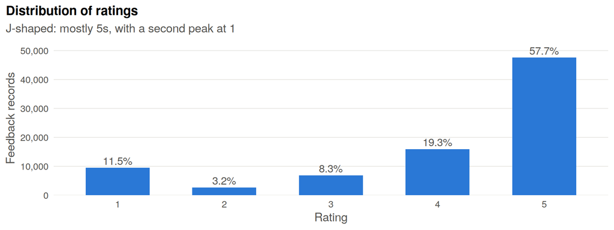

```r
rating_status <- feedback %>% left_join(select(orders, order_id, order_status), by = "order_id") %>%
  group_by(order_status) %>%
  summarise(feedback = n(), mean_rating = mean(rating), pct_rating_1_2 = 100 * mean(rating <= 2)) %>%
  arrange(desc(feedback))
ggplot(count(feedback, rating), aes(factor(rating), n)) +
  geom_col(fill = col_main, width = 0.6) +
  geom_text(aes(label = scales::percent(n / sum(n), accuracy = 0.1)), vjust = -0.4, colour = ink, size = 3.5) +
  scale_y_continuous(labels = scales::comma, expand = expansion(mult = c(0, .12))) +
  labs(title = "Distribution of ratings", subtitle = "J-shaped: mostly 5s, with a second peak at 1",
       x = "Rating", y = "Feedback records")
```

```r
tbl(rating_status, caption = "Ratings by status of the reviewed order")
```

Ratings by status of the reviewed order

| order_status | feedback | mean_rating | pct_rating_1_2 |
| --- | --- | --- | --- |
| COMPLETED | 79,979 | 4.16 | 12.78 |
| IN_TRANSIT | 875 | 2.03 | 68.34 |
| CANCELLED | 504 | 1.81 | 76.59 |
| UNAVAILABLE | 496 | 1.51 | 85.89 |
| BILLED | 266 | 1.66 | 81.95 |
| PROCESSING | 255 | 1.24 | 93.33 |
| PLACED | 3 | 2.33 | 66.67 |
| APPROVED | 2 | 2.50 | 50.00 |

The mean rating (4.09) hides a **J-shaped distribution**. Rating is better treated as ordinal, or as a binary “low rating” (1–2), than as a normally distributed continuous outcome. Fulfilment is strongly linked to satisfaction: completed orders average 4.16, and every other status averages 2.5 or less.

## 9.3 Text indicators

```r
tbl(count(feedback, has_comment, comment_length_positive = comment_length > 0), caption = "has_comment vs comment_length")
```

has_comment vs comment_length

| has_comment | comment_length_positive | n |
| --- | --- | --- |
| FALSE | FALSE | 48,347 |
| TRUE | TRUE | 34,033 |

```r
tbl(feedback %>% group_by(rating) %>%
      summarise(n = n(), pct_with_comment = 100 * mean(has_comment), mean_comment_length = mean(comment_length)),
    caption = "Comments by rating")
```

Comments by rating

| rating | n | pct_with_comment | mean_comment_length |
| --- | --- | --- | --- |
| 1 | 9,462 | 76.29 | 75.95 |
| 2 | 2,632 | 67.36 | 64.85 |
| 3 | 6,826 | 43.70 | 36.22 |
| 4 | 15,900 | 31.38 | 19.29 |
| 5 | 47,560 | 35.89 | 18.58 |

`has_comment` is fully consistent with `comment_length`. Unhappy customers write much more often: about three quarters of 1-star ratings carry a comment, against about a third of 4–5-star ratings.

## 9.4 Timing

```r
fbo <- feedback %>% left_join(select(orders, order_id, purchase_timestamp, delivery_timestamp), by = "order_id") %>%
  mutate(answer_days = as.numeric(difftime(feedback_answered_timestamp, feedback_created_timestamp, units = "days")))
tbl(feedback %>% count(time_of_day = format(feedback_created_timestamp, "%H:%M:%S"),
                       month = format(feedback_created_timestamp, "%m")) %>%
      group_by(time_of_day) %>% summarise(records = sum(n), months = paste(unique(month), collapse = ", ")),
    caption = "Time of day of feedback creation")
```

Time of day of feedback creation

| time_of_day | records | months |
| --- | --- | --- |
| 00:00:00 | 82,309 | 01, 02, 03, 04, 05, 06, 07, 08, 09, 10, 11, 12 |
| 01:00:00 | 71 | 11 |

```r
before_purchase <- sum(as.Date(fbo$feedback_created_timestamp) < as.Date(fbo$purchase_timestamp), na.rm = TRUE)
before_delivery <- sum(as.Date(fbo$feedback_created_timestamp) < as.Date(fbo$delivery_timestamp), na.rm = TRUE)
tbl(numeric_summary(select(fbo, answer_days)), caption = "Days from feedback creation to answer")
```

Days from feedback creation to answer

| variable | n_na | min | p01 | median | mean | p99 | max | n_zero | n_neg |
| --- | --- | --- | --- | --- | --- | --- | --- | --- | --- |
| answer_days | 0 | 0.09 | 0.38 | 1.68 | 3.14 | 21.63 | 518.7 | 0 | 0 |

- Feedback creation is recorded as a **date**. 71 records show 01:00, all in the same month, which looks like a timezone or DST artifact.
- **50 feedback records are dated before the purchase**, which is impossible.
- 4,254 (5.16%) are dated before delivery. These may be complaints about late orders, which matters for any “delay → rating” analysis.
- Feedback is answered after a median of 1.7 days, with a maximum of 519 days.

# 10 Relationships and join behaviour

## 10.1 Referential integrity

```r
fk <- bind_rows(
  check_fk(orders,   "orders",      customers, "customers", "customer_record_id"),
  check_fk(items,    "order_items", orders,    "orders",    "order_id"),
  check_fk(items,    "order_items", products,  "products",  "product_id"),
  check_fk(items,    "order_items", sellers,   "sellers",   "seller_id"),
  check_fk(payments, "payments",    orders,    "orders",    "order_id"),
  check_fk(feedback, "customer_feedback", orders, "orders", "order_id"))
tbl(fk)
```

| relationship | child_rows | unmatched_rows | unmatched_keys | parents_without_child |
| --- | --- | --- | --- | --- |
| orders.customer_record_id → customers | 82,570 | 0 | 0 | 0 |
| order_items.order_id → orders | 93,519 | 0 | 0 | 641 |
| order_items.product_id → products | 93,519 | 15 | 15 | 0 |
| order_items.seller_id → sellers | 93,519 | 0 | 0 | 0 |
| payments.order_id → orders | 86,345 | 0 | 0 | 1 |
| customer_feedback.order_id → orders | 82,380 | 0 | 0 | 645 |

*`unmatched_rows`* are child rows that would be lost in an inner join. *`parents_without_child`* are parent keys with no matching child row. **15 product IDs are sold but missing from `products`.** Every other foreign key resolves.

```r
tbl(orders %>% mutate(has_items = order_id %in% items$order_id, has_payment = order_id %in% payments$order_id,
                      has_feedback = order_id %in% feedback$order_id) %>%
      group_by(order_status) %>%
      summarise(orders = n(), no_items = sum(!has_items), no_payment = sum(!has_payment),
                no_feedback = sum(!has_feedback)) %>% arrange(desc(orders)),
    caption = "Orders without matching child rows, by status")
```

Orders without matching child rows, by status

| order_status | orders | no_items | no_payment | no_feedback |
| --- | --- | --- | --- | --- |
| COMPLETED | 80,082 | 0 | 1 | 542 |
| IN_TRANSIT | 932 | 1 | 0 | 66 |
| CANCELLED | 517 | 130 | 0 | 16 |
| UNAVAILABLE | 507 | 503 | 0 | 12 |
| BILLED | 268 | 2 | 0 | 4 |
| PROCESSING | 257 | 0 | 0 | 3 |
| PLACED | 5 | 5 | 0 | 2 |
| APPROVED | 2 | 0 | 0 | 0 |

Orders without items are almost entirely UNAVAILABLE or CANCELLED. One completed order has no payment record, and 645 orders have no feedback. An inner join to feedback would therefore silently drop them, and that is a possible selection issue.

## 10.2 Cardinality and fan-out

```r
card <- function(x, key) { k <- count(x, .data[[key]]); tibble(min = min(k$n), mean = mean(k$n), max = max(k$n)) }
tbl(bind_rows(
  tibble(join = "customer_record_id in customers") %>% bind_cols(card(customers, "customer_record_id")),
  tibble(join = "customer_id in customers") %>% bind_cols(card(customers, "customer_id")),
  tibble(join = "order_id in order_items") %>% bind_cols(card(items, "order_id")),
  tibble(join = "order_id in payments") %>% bind_cols(card(payments, "order_id")),
  tibble(join = "order_id in customer_feedback") %>% bind_cols(card(feedback, "order_id")),
  tibble(join = "product_id in order_items") %>% bind_cols(card(items, "product_id")),
  tibble(join = "seller_id in order_items") %>% bind_cols(card(items, "seller_id"))),
  caption = "Rows per key value")
```

Rows per key value

| join | min | mean | max |
| --- | --- | --- | --- |
| customer_record_id in customers | 1 | 1.00 | 1 |
| customer_id in customers | 1 | 1.04 | 17 |
| order_id in order_items | 1 | 1.14 | 21 |
| order_id in payments | 1 | 1.05 | 29 |
| order_id in customer_feedback | 1 | 1.01 | 3 |
| product_id in order_items | 1 | 3.18 | 422 |
| seller_id in order_items | 1 | 31.35 | 1,677 |

```r
j1 <- orders %>% left_join(items, by = "order_id", relationship = "many-to-many")
j2 <- j1 %>% left_join(payments, by = "order_id", relationship = "many-to-many")
j3 <- j2 %>% left_join(feedback, by = "order_id", relationship = "many-to-many")
naive_rev <- sum(j3$payment_amount, na.rm = TRUE); true_rev <- sum(payments$payment_amount)
tbl(tibble(step = c("orders", "+ order_items", "+ payments", "+ customer_feedback"),
           rows = c(nrow(orders), nrow(j1), nrow(j2), nrow(j3)),
           distinct_orders = c(n_distinct(orders$order_id), n_distinct(j1$order_id),
                               n_distinct(j2$order_id), n_distinct(j3$order_id))),
    caption = "Naive join of the order-level tables")
```

Naive join of the order-level tables

| step | rows | distinct_orders |
| --- | --- | --- |
| orders | 82,570 | 82,570 |
| + order_items | 94,160 | 82,570 |
| + payments | 98,398 | 82,570 |
| + customer_feedback | 98,987 | 82,570 |

Joining the tables directly multiplies rows. 82,570 orders become 98,987 rows, and **summing `payment_amount` afterwards overstates revenue by 28.76%** (23,448,207 vs 18,210,220). Each table must be aggregated to the chosen unit of observation *before* joining.

# 11 Key findings

1. **Different units of observation.** `order_items`, `payments` and `customer_feedback` all have several rows per order. Naive joins inflate payment totals by 28.76%.
2. **Customer identity.** `customer_record_id` is one record per order. The real person is `customer_id`, and 3.15% of people have several records.
3. **Duplicate item lines.** There are 60 exact duplicates in `order_items`, which payments confirm are errors.
4. **Category labels.** There are 78 raw labels for 73 real categories, and 533 products have no category or listing metadata.
5. **Implausible product weights.** There are 6 values over 100 kg in small boxes (up to 9.4 t), plus 4 zero weights.
6. **Order timeline.** 1,109 orders reach the carrier before approval, and delivery estimates are dates rather than date-times (6.80% late by date).
7. **Payments mostly reconcile** (99.71%). 10 orders were paid exactly 10× the amount due, and there are small anomalies (0 instalments, 0 amounts, UNKNOWN method).
8. **Feedback is many-to-many with orders.** 166 orders carry conflicting ratings, and 50 feedback records predate the purchase.
9. **Ratings are J-shaped and strongly related to fulfilment status**, so they suit ordinal or binary modelling.
10. **Coverage gaps.** 641 orders have no items, 15 sold products are missing from `products`, and the first and last months are sparse.